# Chapter 4 exercises

1/29/2017

```r
suppressWarnings(library(dplyr))
```

## Question 1

Model: $log(weight) = -3.5 + 2 * log(height) + error$

Weight in pounds. height in inches. Error sd = 0.25.

### a) Fill in the blanks (bolded):

Answered using the error sd: ($e^{-0.25}$, $e^{0.25}$)

### b) Plot a scatterplot and regression line for this model.

```r
set.seed(10)

# make up some some simple height input data
height = rnorm(1000, 68, 3)

log_weight = -3.5 + 2 * log(height) + rnorm(1000, 0, 0.25)

q1_model = lm(log_weight ~ log(height))

summary(q1_model)
```

```
##
## Call:
## lm(formula = log_weight ~ log(height))
##
## Residuals:
##      Min       1Q   Median       3Q      Max
## -0.81785 -0.17254  0.00141  0.18356  0.95659
##
## Coefficients:
##             Estimate Std. Error t value Pr(>|t|)
## (Intercept)  -4.6261     0.7943  -5.824 7.73e-09 ***
## log(height)   2.2678     0.1882  12.047  < 2e-16 ***
## ---
## Signif. codes:  0 '***' 0.001 '**' 0.01 '*' 0.05 '.' 0.1 ' ' 1
##
## Residual standard error: 0.2609 on 998 degrees of freedom
## Multiple R-squared:  0.127,  Adjusted R-squared:  0.1261
## F-statistic: 145.1 on 1 and 998 DF,  p-value: < 2.2e-16
```

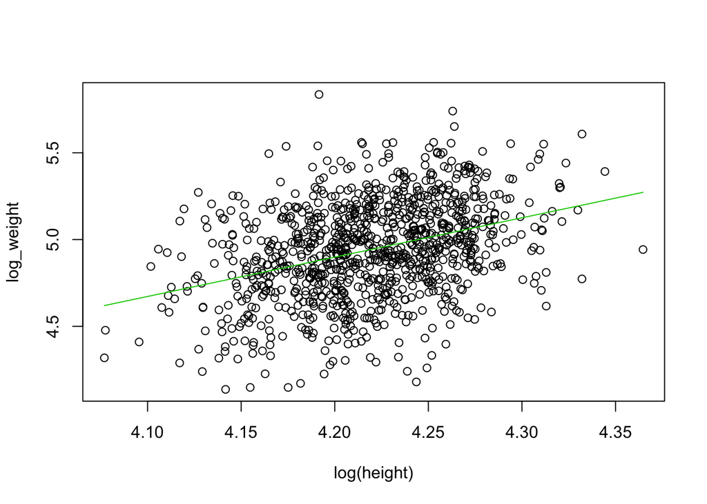

```r
plot(log(height), log_weight)
curve(cbind(1, x) %*% coef(q1_model), add = T, col = 3)
```

## Question 2

Use earnings data: earnings, sex, height, weight

### a) Load and QC the data

There is no weight variable, so I pulled in birth year.

*load:

```r
earnings_dat = dplyr::select(foreign::read.dta("ARM_Data/earnings/heights.dta"),
               earn, sex, height, yearbn)

str(earnings_dat)
```

```
## 'data.frame':    2029 obs. of  4 variables:
##  $ earn  : num  NA NA 50000 60000 30000 NA 50000 NA 51000 9000 ...
##  $ sex   : int  2 1 1 2 2 2 2 2 2 2 ...
##  $ height: num  66 64 74 66 64 65 63 68 63 64 ...
##  $ yearbn: num  53 50 45 32 61 33 99 36 51 64 ...
##  - attr(*, "datalabel")= chr ""
##  - attr(*, "time.stamp")= chr "25 Aug 2003 11:32"
##  - attr(*, "formats")= chr  "%9.0g" "%8.0g" "%9.0g" "%8.0g" ...
##  - attr(*, "types")= int  102 98 102 98 98 98 102 102 102
##  - attr(*, "val.labels")= chr  "" "" "" "" ...
##  - attr(*, "var.labels")= chr  "" "" "" "" ...
##  - attr(*, "version")= int 7
```

*check the variables

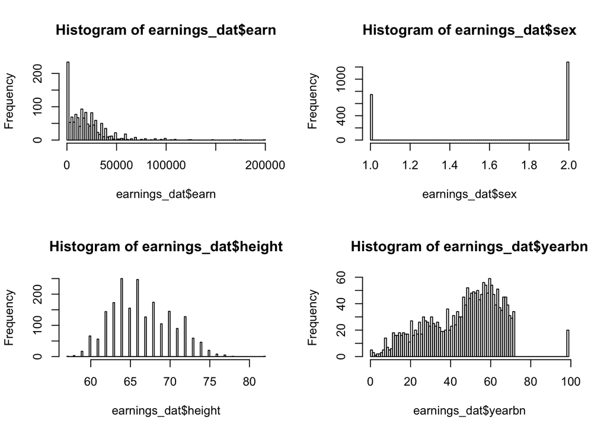

```r
par(mfrow = c(2,2))
hist(earnings_dat$earn, breaks = 100)
hist(earnings_dat$sex, breaks = 100)
hist(earnings_dat$height, breaks = 100)
hist(earnings_dat$yearbn, breaks = 100) #
```

```r
par(mfrow = c(1,1))
ftable(cut(earnings_dat$earn, breaks = c(0, 1, 10, Inf), right = F))
```

```
##  [0,1) [1,10) [10,Inf)
##
##    187      0     1192
```

Earnings has a bunch of 0s and NAs. 0s are odd so I will remove them, IRL this should be investigated further. There is a bump in yearbn at 99, probably a missing code so will remove those too.

*complete case for covenience, make final variables

```r
earnings_clean = subset(earnings_dat, !is.na(earn) & earn > 0 & yearbn < 99)

#stole these from other person posting answers
earnings_clean$earn = earnings_clean$earn/1000
earnings_clean$sex = factor(earnings_clean$sex, labels=c("male", "female"),
                            ordered = F)

#note that once you center birth year that the interpretation is the same as decreasing age, so flip the sign to represent getting older. See below.
earnings_clean$yearbn_ctr =  earnings_clean$yearbn - mean(earnings_clean$yearbn)
earnings_clean$age_yrs_ctr = mean(earnings_clean$yearbn) - earnings_clean$yearbn
mean(earnings_clean$yearbn)
```

```
## [1] 48.74685
```

Age$_i$ = current_year - $yearbn_i$

Age_center$_i$ = Age$_i$ - E[Age]  
Age_center$_i$ = current_year - $yearbn_i$ - E[current_year - $yearbn$]  
Age_center$_i$ = E[$yearbn$] - $yearbn_i$.

The range of this variable is 72 years, which means it could range from like 16 to 89.

I chose to the yearbn centered variable (average year 1949) because I think the interpretation is actually clearer than ages without a reference year.

### b) Run model: earnings ~ height. Transform the data so that the intercept is the average earnings at the average height.

Center height at mean. **Intercept earnings move from -62K to 23K with transformation.** Note how the rest of the model is unaffected.

```r
earn_model2b = lm(earn ~ height, data = earnings_clean)
summary(earn_model2b)
```

```
##
## Call:
## lm(formula = earn ~ height, data = earnings_clean)
##
## Residuals:
##     Min      1Q  Median      3Q     Max
## -30.211 -11.318  -3.403   6.579 172.953
##
## Coefficients:
##             Estimate Std. Error t value Pr(>|t|)
## (Intercept) -61.9295     9.5407  -6.491 1.25e-10 ***
## height        1.2711     0.1423   8.930  < 2e-16 ***
## ---
## Signif. codes:  0 '***' 0.001 '**' 0.01 '*' 0.05 '.' 0.1 ' ' 1
##
## Residual standard error: 18.87 on 1187 degrees of freedom
## Multiple R-squared:  0.06295,    Adjusted R-squared:  0.06216
## F-statistic: 79.74 on 1 and 1187 DF,  p-value: < 2.2e-16
```

```r
earnings_clean$height_ctr = earnings_clean$height - mean(earnings_clean$height)


earn_model2b_2 = lm(earn ~ height_ctr, data = earnings_clean)
summary(earn_model2b_2)
```

```
##
## Call:
## lm(formula = earn ~ height_ctr, data = earnings_clean)
##
## Residuals:
##     Min      1Q  Median      3Q     Max
## -30.211 -11.318  -3.403   6.579 172.953
##
## Coefficients:
##             Estimate Std. Error t value Pr(>|t|)
## (Intercept)  23.1283     0.5471   42.27   <2e-16 ***
## height_ctr    1.2711     0.1423    8.93   <2e-16 ***
## ---
## Signif. codes:  0 '***' 0.001 '**' 0.01 '*' 0.05 '.' 0.1 ' ' 1
##
## Residual standard error: 18.87 on 1187 degrees of freedom
## Multiple R-squared:  0.06295,    Adjusted R-squared:  0.06216
## F-statistic: 79.74 on 1 and 1187 DF,  p-value: < 2.2e-16
```

### c) Fit some models

Will try transforming earnings because of the skew. I normalized height ignoring issues with sex. Year born was scaled in decade increments.

Trying the following models (set up *a prior*): 1. All three predictors (height, sex, yearbn): with log earn and without to test log transform diagnostics.  
2. Sex and yearbn interaction.  
3. Sex and height interaction: will include sex*yearbn depending on results.

Note that mean height is 67 inches and mean year born is 1949. Earnings is scaled by $1000.

Models 1:  
The diagnostics for this model are not great, there seems to be some clusters.

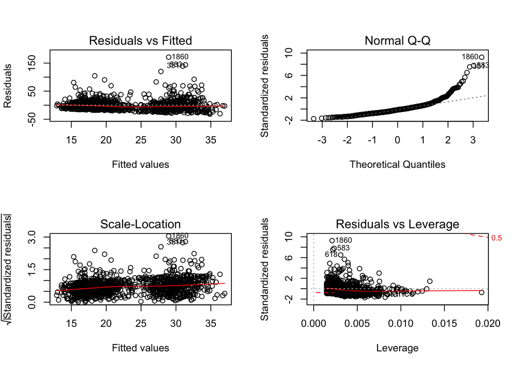

```r
# earnings_clean = earnings_clean %>% group_by(sex) %>%
#   mutate(mean_height = mean(height), sd_height = sd(height)) %>%
#   ungroup() %>%
#   rowwise() %>% mutate(height_norm_sex = (height - mean_height)/sd_height)

earnings_clean$log_earn = log(earnings_clean$earn)
earnings_clean$height_norm = earnings_clean$height_ctr/sd(earnings_clean$height)
earnings_clean$yearbn_ctr_decade = earnings_clean$yearbn_ctr/10
earnings_clean$log_earn = log(earnings_clean$earn)

earn_model_1a = lm(earn ~ height_norm + yearbn_ctr_decade + sex, data = earnings_clean)
earn_model_1b = lm(log_earn ~ height_norm + yearbn_ctr_decade + sex, data = earnings_clean)
# earn_model_1c = lm(log_earn ~ height_norm_sex + yearbn_ctr_decade + sex, data = earnings_clean)

par(mfrow = c(2, 2))
plot(earn_model_1a)
```

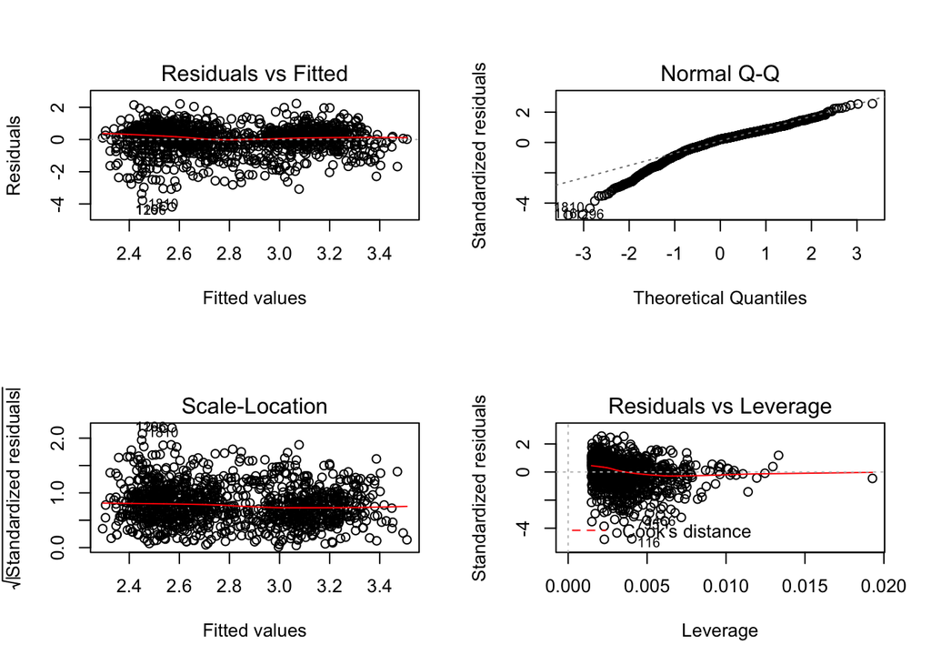

```r
plot(earn_model_1b)
```

Model 2: going with the log_earn model because it somewhat controls the outlying residuals a little better.

```r
earn_model_2 = lm(log_earn ~ height_norm + yearbn_ctr_decade * sex, data = earnings_clean)

summary(earn_model_2)
```

```
##
## Call:
## lm(formula = log_earn ~ height_norm + yearbn_ctr_decade * sex,
##     data = earnings_clean)
##
## Residuals:
##     Min      1Q  Median      3Q     Max
## -4.2114 -0.3931  0.1727  0.5583  2.2649
##
## Coefficients:
##                             Estimate Std. Error t value Pr(>|t|)
## (Intercept)                  3.04895    0.04853  62.821  < 2e-16 ***
## height_norm                  0.09920    0.03574   2.776   0.0056 **
## yearbn_ctr_decade           -0.12630    0.02500  -5.052 5.07e-07 ***
## sexfemale                   -0.41609    0.07178  -5.797 8.67e-09 ***
## yearbn_ctr_decade:sexfemale  0.08627    0.03273   2.636   0.0085 **
## ---
## Signif. codes:  0 '***' 0.001 '**' 0.01 '*' 0.05 '.' 0.1 ' ' 1
##
## Residual standard error: 0.8711 on 1184 degrees of freedom
## Multiple R-squared:  0.1091, Adjusted R-squared:  0.1061
## F-statistic: 36.24 on 4 and 1184 DF,  p-value: < 2.2e-16
```

Model 3: leaving in sex/yearbn interaction

```r
earn_model_3 = lm(log_earn ~ yearbn_ctr_decade * sex + height_norm * yearbn_ctr_decade, data = earnings_clean)

summary(earn_model_3)
```

```
##
## Call:
## lm(formula = log_earn ~ yearbn_ctr_decade * sex + height_norm *
##     yearbn_ctr_decade, data = earnings_clean)
##
## Residuals:
##     Min      1Q  Median      3Q     Max
## -4.1845 -0.4065  0.1767  0.5463  2.3356
##
## Coefficients:
##                                Estimate Std. Error t value Pr(>|t|)
## (Intercept)                    3.056253   0.048479  63.043  < 2e-16 ***
## yearbn_ctr_decade             -0.086772   0.028882  -3.004  0.00272 **
## sexfemale                     -0.414087   0.071595  -5.784 9.34e-09 ***
## height_norm                    0.099256   0.035646   2.784  0.00545 **
## yearbn_ctr_decade:sexfemale    0.004183   0.044517   0.094  0.92515
## yearbn_ctr_decade:height_norm -0.058681   0.021637  -2.712  0.00678 **
## ---
## Signif. codes:  0 '***' 0.001 '**' 0.01 '*' 0.05 '.' 0.1 ' ' 1
##
## Residual standard error: 0.8688 on 1183 degrees of freedom
## Multiple R-squared:  0.1146, Adjusted R-squared:  0.1108
## F-statistic: 30.62 on 5 and 1183 DF,  p-value: < 2.2e-16
```

```r
earn_model_3b = lm(log_earn ~ sex + height_norm * yearbn_ctr_decade, data = earnings_clean)

summary(earn_model_3b)
```

```
##
## Call:
## lm(formula = log_earn ~ sex + height_norm * yearbn_ctr_decade,
##     data = earnings_clean)
##
## Residuals:
##     Min      1Q  Median      3Q     Max
## -4.1831 -0.4077  0.1768  0.5467  2.3359
##
## Coefficients:
##                               Estimate Std. Error t value Pr(>|t|)
## (Intercept)                    3.05622    0.04846  63.070  < 2e-16 ***
## sexfemale                     -0.41388    0.07153  -5.786 9.22e-09 ***
## height_norm                    0.09932    0.03562   2.788  0.00539 **
## yearbn_ctr_decade             -0.08454    0.01637  -5.164 2.84e-07 ***
## height_norm:yearbn_ctr_decade -0.06006    0.01586  -3.787  0.00016 ***
## ---
## Signif. codes:  0 '***' 0.001 '**' 0.01 '*' 0.05 '.' 0.1 ' ' 1
##
## Residual standard error: 0.8684 on 1184 degrees of freedom
## Multiple R-squared:  0.1146, Adjusted R-squared:  0.1116
## F-statistic:  38.3 on 4 and 1184 DF,  p-value: < 2.2e-16
```

It seems that the height*year interaction might explain some of the sex*interaction. So I removed the latter. The R-sq remains the same (11%). The model doesn’t explain a lot of the variance and the diagnostics aren’t great.

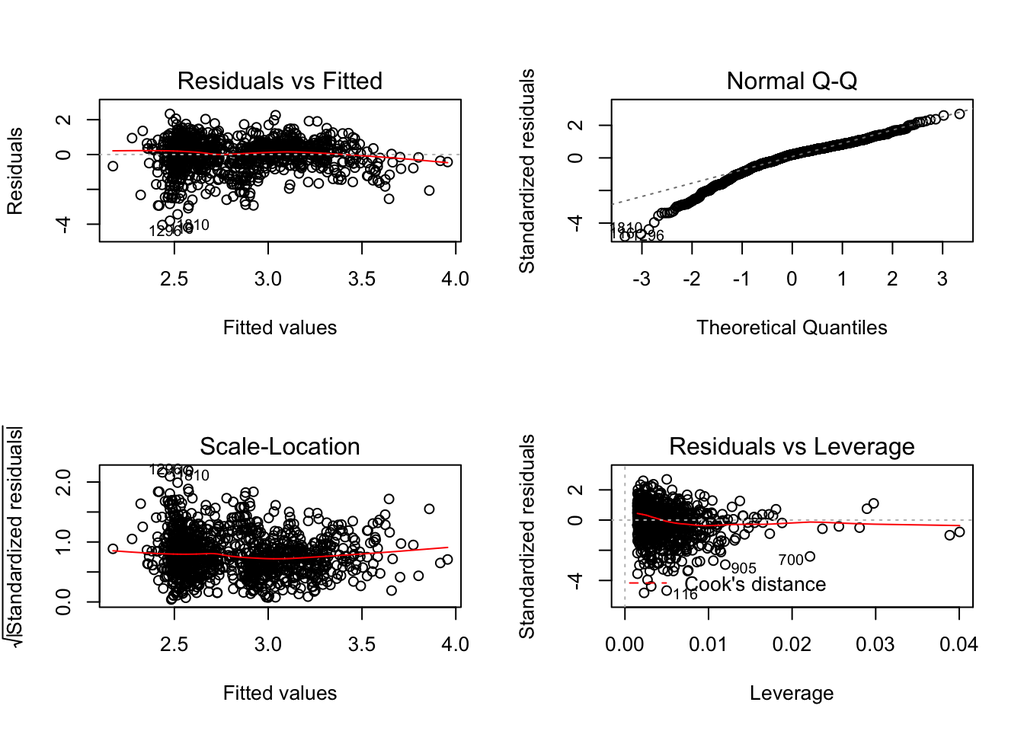

```r
par(mfrow = c(2, 2))

plot(earn_model_3b)
```

### c) Interpret the model coefficients:

Note: x times difference can be rescaled relative to 1 and interpretted as percentage. If you deal with risk differences (arithmetic differences in risk), this is confusing.

Intercept: The average earnings are $21K for a male of average population height (67 inches) born in 1949.

height_norm: Earnings increase an average 1.1 ($e^{0.099}$) times per std. deviation increase in height between two people of the same sex born in 1949.

yearbn_ctr_decade: Earnings decrease an average 0.91 ($e^{-0.085}$) times per decade increase in birth year between two people of the same sex who are 67 inches in height.

## Question 3

The following was generated from a regression of weight on age per 10 years. The output was provided and curated by IamGianluca on github.

```r
lm(formula = weight ~ age10)
                  coef.est coef.se
(Intercept)       161.0     7.3
age10             2.6       1.6
---
  n = 2009, k = 2
  residual sd = 119.7, R-Squared = 0.00


lm(formula = weight ~ age10 + age10.sq)
                  coef.est coef.se
(Intercept)       96.2      19.3
age10             33.6      8.7
age10.sq          -3.2      0.9
---
  n = 2009, k = 3,
  residual sd = 119.3, R-Squared = 0.01


lm(formula = weight ~ age30.44 + age45.64 + age65up)
                  coef.est coef.se
(Intercept)       157.2    5.4
age30.44TRUE      19.1     7.0
age45.64TRUE      27.2     7.6
age65upTRUE       8.5      8.7
---
  n = 2009, k = 4
  residual sd = 119.4, R-Squared = 0.01
```

### a-c) plot the regression results for each model.

(I’m assuming age ranges between 18 and 80)

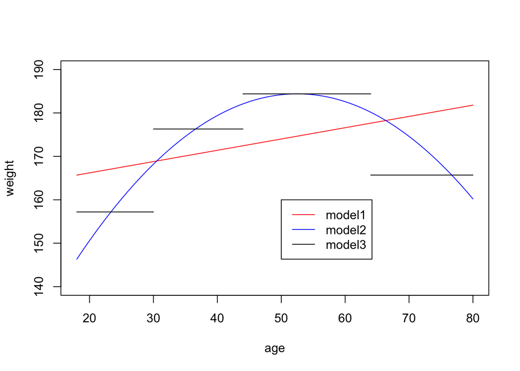

```r
par(mfrow = c(1,1))
age = seq(18,80, by = 1)
weight = seq(140, 190, length = length(age))

plot(age, weight, "n")
curve(cbind(1, x/10) %*% c(161, 2.6), add = T, col = "red")
curve(cbind(1, x/10, x^2/100) %*% c(96.2, 33.6, -3.2), add = T, col = "blue")
#model 3
curve(cbind(1,x) %*% c(157.2, 0), add = T, xlim = c(18, 30))
curve(cbind(1,x) %*% c(157.2 + 19.1, 0), add = T, xlim = c(30, 44))
curve(cbind(1,x) %*% c(157.2 + 27.2, 0), add = T, xlim = c(44, 64))
curve(cbind(1,x) %*% c(157.2 + 8.5, 0), add = T, xlim = c(64, 80))
legend(x = 50, 160, c("model1", "model2", "model3"), lty = 1, col = c("red", "blue", "black"))
```

## Question 4

Using `pollution` data.

```r
pollution = foreign::read.dta("http://www.stat.columbia.edu/~gelman/arm/examples/pollution/pollution.dta")
```

### a) Plot and fit an lm of mortality rate versus nitric oxide. Show diagnostics.

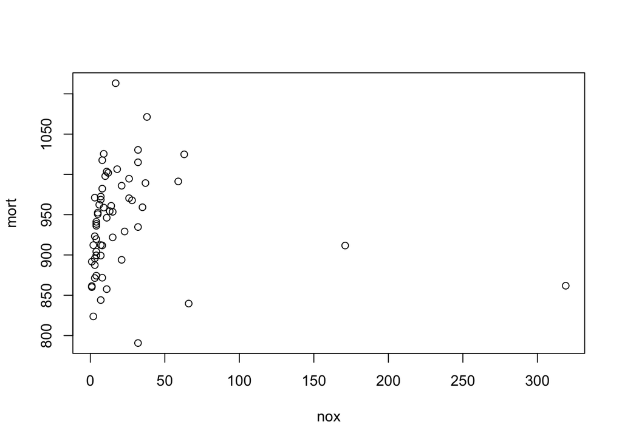

```r
with(pollution, plot(nox, mort))
```

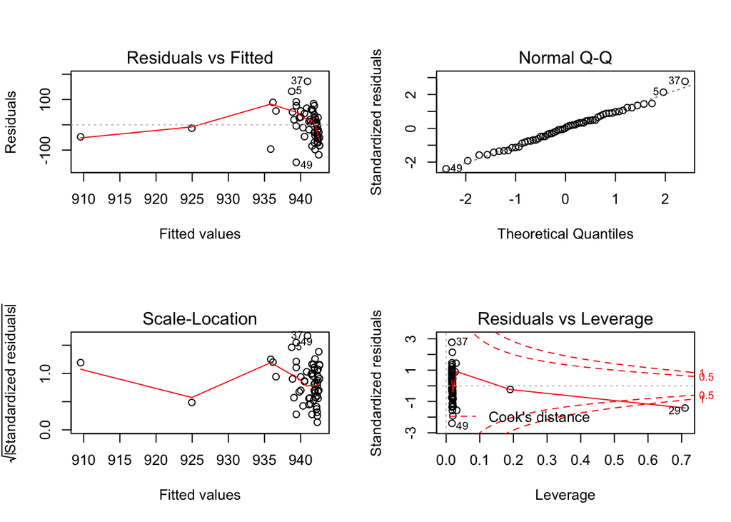

```r
model4a = lm(mort ~ nox, data = pollution)
par(mfrow = c(2,2))
plot(model4a)
```

```r
par(mfrow = c(1,1))
```

### b) Transform the data to adjust for issues seen in a)

log looks good for the nox variable. Using a log(predictor), choose a base that makes the interpretation works. Otherwise, Log the outcome and use the elasticity interpretation. Choosing the former.

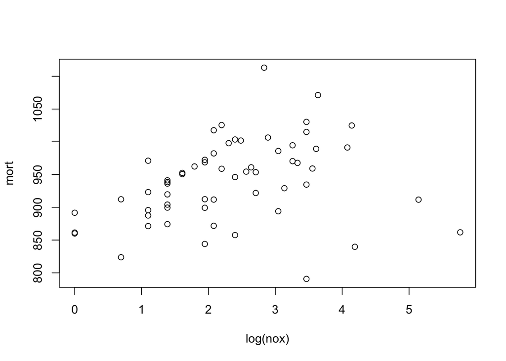

```r
with(pollution, plot(log(nox), mort))
```

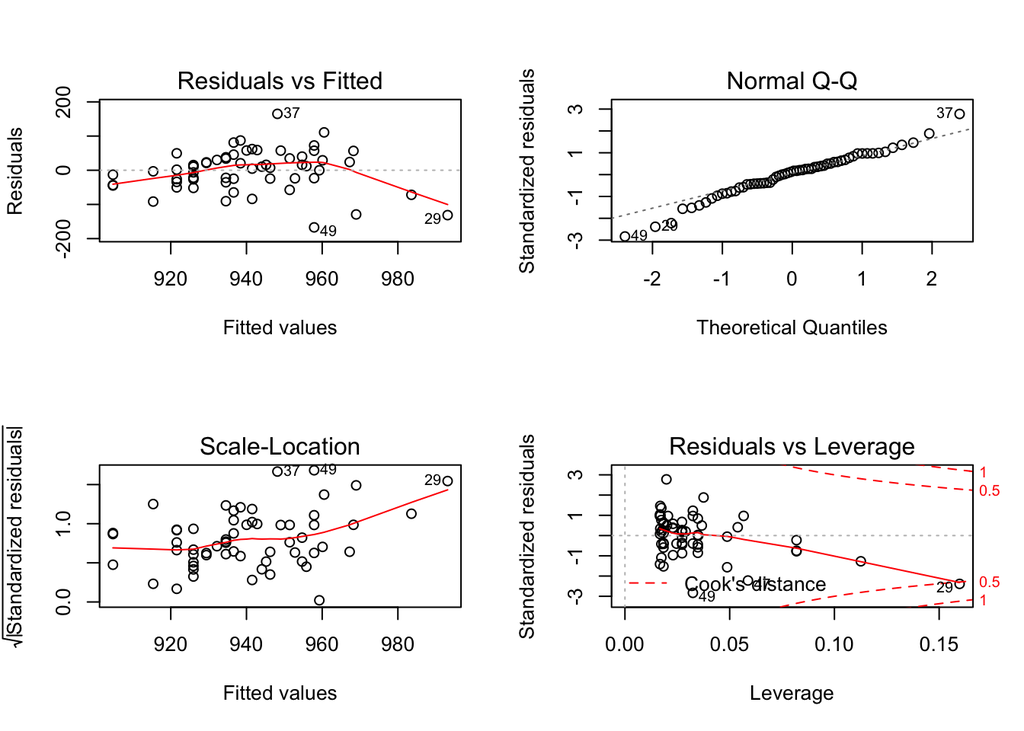

```r
model4b1 = lm(mort ~ log10(nox), data = pollution)
model4b2 = lm(log(mort) ~ log(nox), data = pollution)

par(mfrow = c(2,2))
plot(model4b1)
```

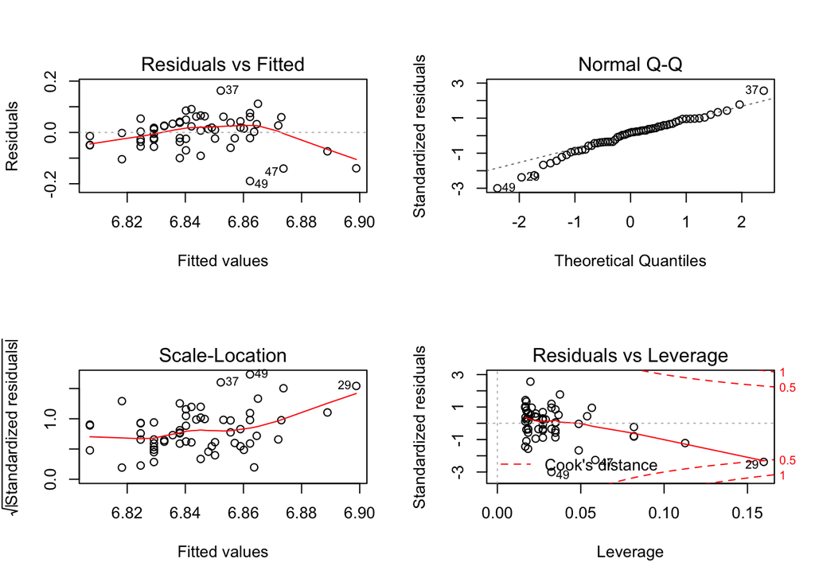

```r
plot(model4b2)
```

```r
par(mfrow = c(1,1))

summary(model4b1)
```

```
##
## Call:
## lm(formula = mort ~ log10(nox), data = pollution)
##
## Residuals:
##      Min       1Q   Median       3Q      Max
## -167.140  -28.368    8.778   35.377  164.983
##
## Coefficients:
##             Estimate Std. Error t value Pr(>|t|)
## (Intercept)   904.72      17.17  52.684   <2e-16 ***
## log10(nox)     35.31      15.19   2.325   0.0236 *
## ---
## Signif. codes:  0 '***' 0.001 '**' 0.01 '*' 0.05 '.' 0.1 ' ' 1
##
## Residual standard error: 60.01 on 58 degrees of freedom
## Multiple R-squared:  0.08526,    Adjusted R-squared:  0.06949
## F-statistic: 5.406 on 1 and 58 DF,  p-value: 0.02359
```

```r
#summary(model4b2)
```

### d) Add in sulfur dioxide and hydrocarbons

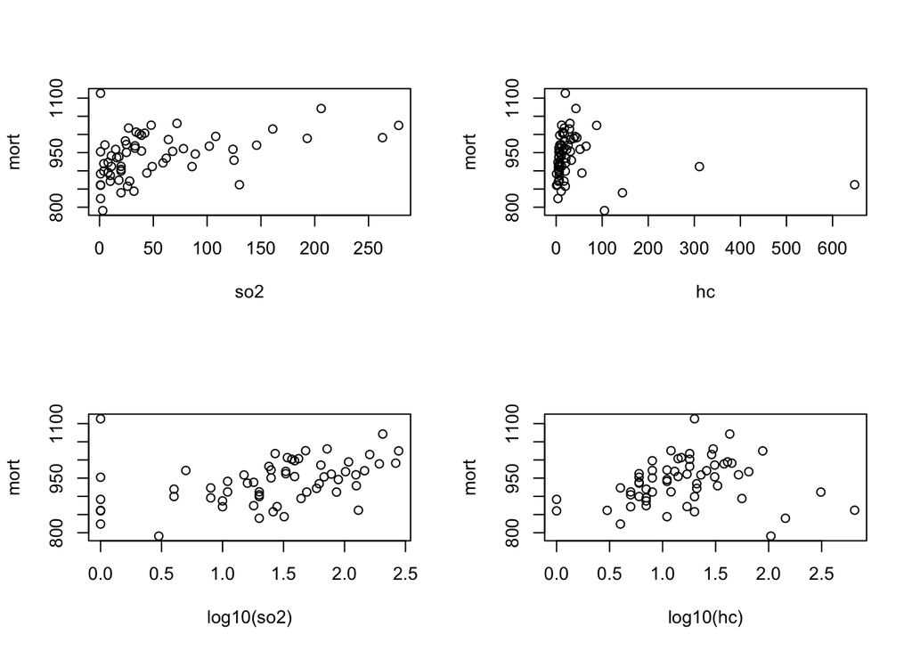

```r
par(mfrow = c(2,2))
with(pollution, {plot(so2, mort); plot(hc, mort)})
with(pollution, {plot(log10(so2), mort); plot(log10(hc), mort)})
```

```r
model_4d = lm(mort ~ log10(nox) + log10(so2) + log10(hc), data = pollution)
summary(model_4d)
```

```
##
## Call:
## lm(formula = mort ~ log10(nox) + log10(so2) + log10(hc), data = pollution)
##
## Residuals:
##     Min      1Q  Median      3Q     Max
## -97.793 -34.728  -3.118  34.148 194.567
##
## Coefficients:
##             Estimate Std. Error t value Pr(>|t|)
## (Intercept)   924.97      21.45  43.125  < 2e-16 ***
## log10(nox)    134.32      50.08   2.682  0.00960 **
## log10(so2)     27.08      16.50   1.642  0.10629
## log10(hc)    -131.94      44.71  -2.951  0.00462 **
## ---
## Signif. codes:  0 '***' 0.001 '**' 0.01 '*' 0.05 '.' 0.1 ' ' 1
##
## Residual standard error: 54.36 on 56 degrees of freedom
## Multiple R-squared:  0.2752, Adjusted R-squared:  0.2363
## F-statistic: 7.086 on 3 and 56 DF,  p-value: 0.0004044
```

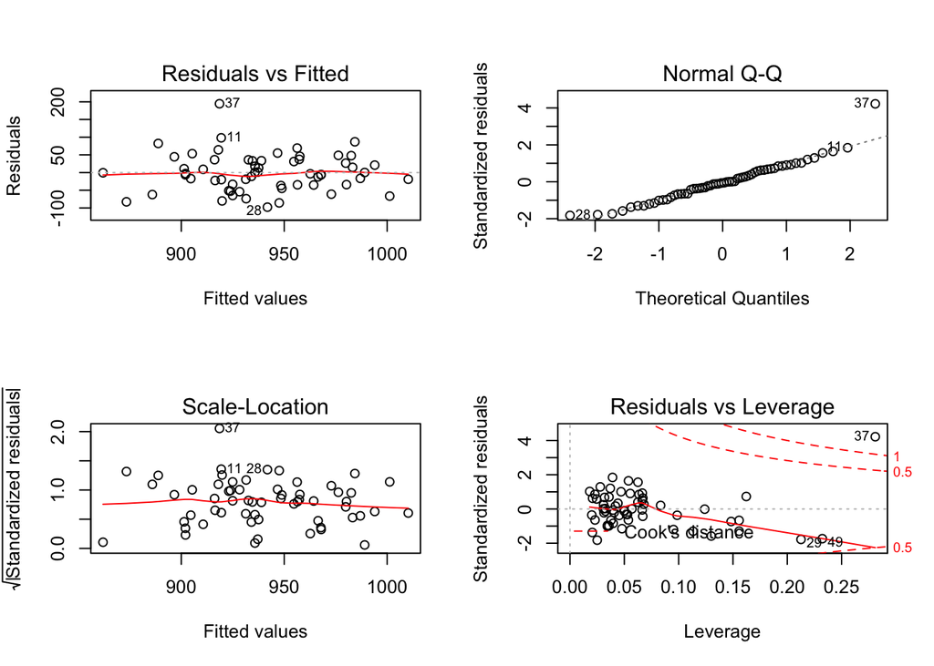

```r
plot(model_4d)
```

Model seems ok (24% R-sq), there is an outlier (low so2).

### e) cross-validation, use model in d) to fit half of data then predict second half

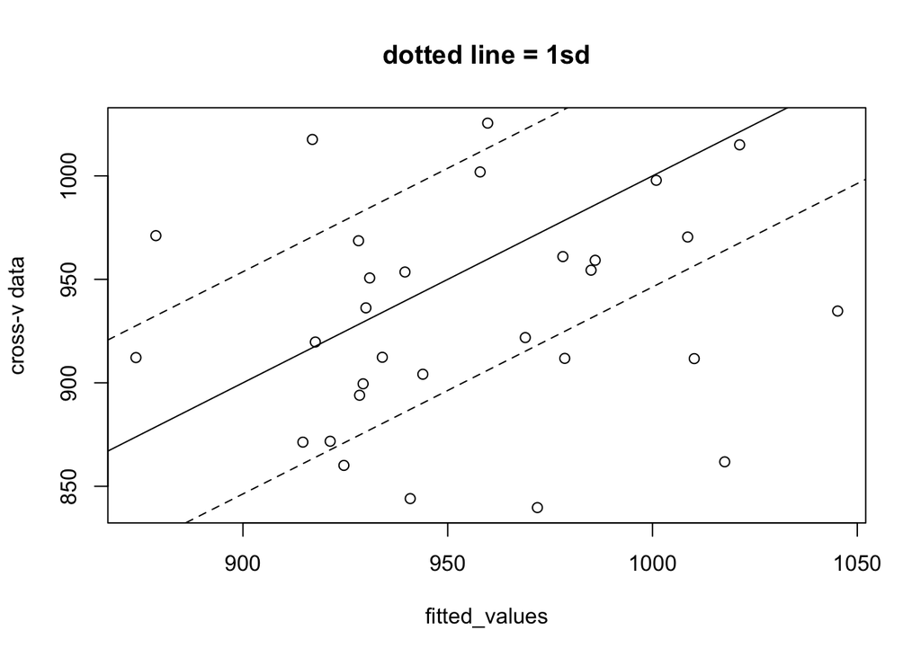

```r
set.seed(15)
row_sample = sample(dim(pollution)[1], round(dim(pollution)[1]/2))

model_4e = lm(mort ~ log10(nox) + log10(so2) + log10(hc), data = pollution[row_sample, ])

fitted_values = predict(model_4e, pollution[-row_sample, ])

plot(fitted_values, pollution[-row_sample, "mort"], ylab = "cross-v data", main = "dotted line = 1sd")
abline(0, 1)
abline(summary(model_4e)$sigma, 1, lty = 2)
abline(-summary(model_4e)$sigma, 1, lty = 2)
```

## Question 6. Interpret the coefficient in the following model:

Model: $log(Q) = \alpha + \beta log(P)$.  
Q = smokes bought.  
P = cost of cigarettes.  
unit = counties in US. $\beta = 0.3$

Per every unit increase in average price in cigarettes, the purchased quantity inceases by 1.35 ($e^{0.3}$) times.